# Burritos Data - plots

Saurabh Sharma

November 16, 2018

1. Create a variable called ritos and store your data in in.

```r
getwd()
```

```
## [1] "E:/R Files"
```

```r
ritos = read.csv("Burritos_Data.csv")
```

2. Print the first 6 rows of ritos

```r
head(ritos)
```

```
##                 Location     Burrito      Date Neighborhood
## 1   graciela's taco shop    adobada  2/14/2016  chula vista
## 2   graciela's taco shop    barbacoa 2/14/2016  chula vista
## 3    cortez mexican food california  10/7/2016      bonsall
## 4 el pueblo mexican food  california 8/10/2016     cardiff
## 5           pollos maria  california 1/27/2016     carlsbad
## 6         senor grubby's  california 4/24/2016     carlsbad
##                   Address Yelp Google Chips Cost Hunger Length Circum
## 1        5047 Central Ave  4.0    4.5    No 5.99      3     NA     NA
## 2        5047 Central Ave  4.0    4.5    No 5.99      2     NA     NA
## 3         5517 Mission Rd  4.2    4.0    No 6.25      4   22.5   18.0
## 4       820 Birmingham Dr  4.0    4.7    No 4.99      4   19.0   21.0
## 5         3055 Harding St  4.0    3.8   Yes 6.59      4     NA     NA
## 6 377 Carlsbad Village Dr  4.0    4.1    No 9.00      2   19.0   21.5
##   Volume Tortilla Temp Meat Fillings Meat.filling Uniformity Salsa Synergy
```

[output cut: 48 more lines]

3. Print the dimension of ritos

```r
dim(ritos)
```

```
## [1] 339  63
```

4. Filter the data using variable nonSD == 0, store it in ritos and print the dimension of this dataset

```r
library(dplyr)
ritos = filter(ritos, NonSD == 0)
dim(ritos)
```

```
## [1] 332  63
```

5. Print the number of unique values for Burito variable

```r
u = length(unique(ritos$Burrito))
u
```

```
## [1] 93
```

6. Using the Burito variable, filter data for california and print the number of unique values for the same. Hint : Use grepl to filter ‘california’

```r
b = table(grepl("california", ritos$Burrito))
length(unique(b))
```

```
## [1] 2
```

7. Select the variables Location and Yelp and print the first 6 rows

```r
r = select(ritos, c(Location,Yelp))
head(r)
```

```
##                 Location Yelp
## 1   graciela's taco shop  4.0
## 2   graciela's taco shop  4.0
## 3    cortez mexican food  4.2
## 4 el pueblo mexican food  4.0
## 5           pollos maria  4.0
## 6         senor grubby's  4.0
```

8. Select columns with Burito ratings i.e. from Tortilla to Wrap and print the first 6 rows

```r
as = select(ritos,Tortilla : Wrap)
head(as)
```

```
##   Tortilla Temp Meat Fillings Meat.filling Uniformity Salsa Synergy Wrap
## 1      4.0  4.0  3.0      3.5          4.0        4.5   4.0     4.0  4.5
## 2      3.5  4.0  3.5       NA          4.0         NA   4.0     4.0  1.5
## 3      3.5  4.0  2.5      3.0          1.5        2.5   2.5     2.8  5.0
## 4      4.5  4.5  3.5      4.0          4.5        5.0   2.5     4.5  5.0
## 5      4.0  5.0  4.0      3.5          4.5        5.0   2.5     4.5  4.0
## 6      2.0  3.5  3.0      1.5          1.0        1.0   2.5     1.5  3.5
```

9. Create a new data frame df from ritos, select only columns ‘Taste’, ‘Rec’, ‘Cost’, ’Volume

```r
df = data.frame(ritos)
select(df, c(Taste,Rec,Cost,Volume))
```

```
##       Taste  Rec  Cost Volume
## 1   4.00000 <NA>  5.99     NA
## 2   4.00000 <NA>  5.99     NA
## 3   3.20000   no  6.25   0.58
## 4   4.30000  yes  4.99   0.67
## 5   4.20000 <NA>  6.59     NA
## 6   1.50000   no  9.00   0.70
## 7   3.00000 <NA>  7.00     NA
## 8   3.50000   no  6.49   0.40
## 9   2.75000  yes  7.15   0.92
## 10  3.20000 <NA>  6.99     NA
## 11  3.80000  yes  6.99   0.83
## 12  4.00000  yes  7.00     NA
## 13  1.80000   no  9.00   0.78
## 14  3.80000 <NA>  6.00     NA
```

[output cut: 318 more lines]

10. Create a new column(‘Cost_vol’) in the same dataframe df using the formula(Cost/Volume), print the first 6 rows of the df

```r
h = mutate(df, Cost_vol = Cost/Volume)
h
```

```
##                                                Location
## 1                                  graciela's taco shop
## 2                                  graciela's taco shop
## 3                                   cortez mexican food
## 4                                el pueblo mexican food
## 5                                          pollos maria
## 6                                        senor grubby's
## 7                             lola's 7 up market & deli
## 8                                          pollos maria
## 9                                              chipotle
## 10                                         pollos maria
## 11                                         pollos maria
## 12                                             chipotle
## 13                                       senor grubby's
## 14                            lola's 7 up market & deli
```

[output cut: 3315 more lines]

```r
head(h)
```

```
##                 Location     Burrito      Date Neighborhood
## 1   graciela's taco shop    adobada  2/14/2016  chula vista
## 2   graciela's taco shop    barbacoa 2/14/2016  chula vista
## 3    cortez mexican food california  10/7/2016      bonsall
## 4 el pueblo mexican food  california 8/10/2016     cardiff
## 5           pollos maria  california 1/27/2016     carlsbad
## 6         senor grubby's  california 4/24/2016     carlsbad
##                   Address Yelp Google Chips Cost Hunger Length Circum
## 1        5047 Central Ave  4.0    4.5    No 5.99      3     NA     NA
## 2        5047 Central Ave  4.0    4.5    No 5.99      2     NA     NA
## 3         5517 Mission Rd  4.2    4.0    No 6.25      4   22.5   18.0
## 4       820 Birmingham Dr  4.0    4.7    No 4.99      4   19.0   21.0
## 5         3055 Harding St  4.0    3.8   Yes 6.59      4     NA     NA
## 6 377 Carlsbad Village Dr  4.0    4.1    No 9.00      2   19.0   21.5
##   Volume Tortilla Temp Meat Fillings Meat.filling Uniformity Salsa Synergy
```

[output cut: 48 more lines]

11. Select burrito rating variable and recommendation(select variable rec and Tortilla to Taste), store this in a new variable called ing and print the first 6 rows

```r
ing = select(ritos, c(Rec,Tortilla : Taste))
ing
```

```
##      Rec Tortilla Temp Meat Fillings Meat.filling Uniformity Salsa Synergy
## 1   <NA>     4.00  4.0 3.00     3.50         4.00        4.5  4.00    4.00
## 2   <NA>     3.50  4.0 3.50       NA         4.00         NA  4.00    4.00
## 3     no     3.50  4.0 2.50     3.00         1.50        2.5  2.50    2.80
## 4    yes     4.50  4.5 3.50     4.00         4.50        5.0  2.50    4.50
## 5   <NA>     4.00  5.0 4.00     3.50         4.50        5.0  2.50    4.50
## 6     no     2.00  3.5 3.00     1.50         1.00        1.0  2.50    1.50
## 7   <NA>     2.50  3.0 3.00     4.00         2.00        2.0  3.00    3.50
## 8     no     3.50  4.0 3.00     4.00         3.50        4.0  3.00    4.00
## 9    yes     2.50  2.5 3.00     2.80         2.50        3.5    NA    3.00
## 10  <NA>     3.00  4.0 5.00     3.50         2.50        2.5  2.50    4.00
## 11   yes     3.50  2.5 4.00     3.50         3.00        2.5  2.50    4.50
## 12   yes     3.00   NA 5.00     3.00         3.00        4.0  4.00    4.00
## 13    no     2.50  2.5 1.50     2.50         1.00        2.0  2.50    2.00
## 14  <NA>     2.50  2.5 3.00     4.00         4.00        4.0  3.00    3.50
```

[output cut: 651 more lines]

12. Convert the above data to long format and store in variable df.melt; use ‘Rec’ and ‘Taste’ as your id variables, print the structure of this dataset

```r
library("UsingR")
library("reshape2")
df.melt = melt(ing, id = c("Rec", "Taste"))
df.melt
```

```
##       Rec   Taste     variable value
## 1    <NA> 4.00000     Tortilla  4.00
## 2    <NA> 4.00000     Tortilla  3.50
## 3      no 3.20000     Tortilla  3.50
## 4     yes 4.30000     Tortilla  4.50
## 5    <NA> 4.20000     Tortilla  4.00
## 6      no 1.50000     Tortilla  2.00
## 7    <NA> 3.00000     Tortilla  2.50
## 8      no 3.50000     Tortilla  3.50
## 9     yes 2.75000     Tortilla  2.50
## 10   <NA> 3.20000     Tortilla  3.00
## 11    yes 3.80000     Tortilla  3.50
## 12    yes 4.00000     Tortilla  3.00
## 13     no 1.80000     Tortilla  2.50
## 14   <NA> 3.80000     Tortilla  2.50
```

[output cut: 2974 more lines]

```r
structure(df.melt)
```

```
##       Rec   Taste     variable value
## 1    <NA> 4.00000     Tortilla  4.00
## 2    <NA> 4.00000     Tortilla  3.50
## 3      no 3.20000     Tortilla  3.50
## 4     yes 4.30000     Tortilla  4.50
## 5    <NA> 4.20000     Tortilla  4.00
## 6      no 1.50000     Tortilla  2.00
## 7    <NA> 3.00000     Tortilla  2.50
## 8      no 3.50000     Tortilla  3.50
## 9     yes 2.75000     Tortilla  2.50
## 10   <NA> 3.20000     Tortilla  3.00
## 11    yes 3.80000     Tortilla  3.50
## 12    yes 4.00000     Tortilla  3.00
## 13     no 1.80000     Tortilla  2.50
## 14   <NA> 3.80000     Tortilla  2.50
```

[output cut: 2974 more lines]

13. Plot(ggplot and geom_point) the above dataset using x variable ‘Taste’ and y variable ‘Value’

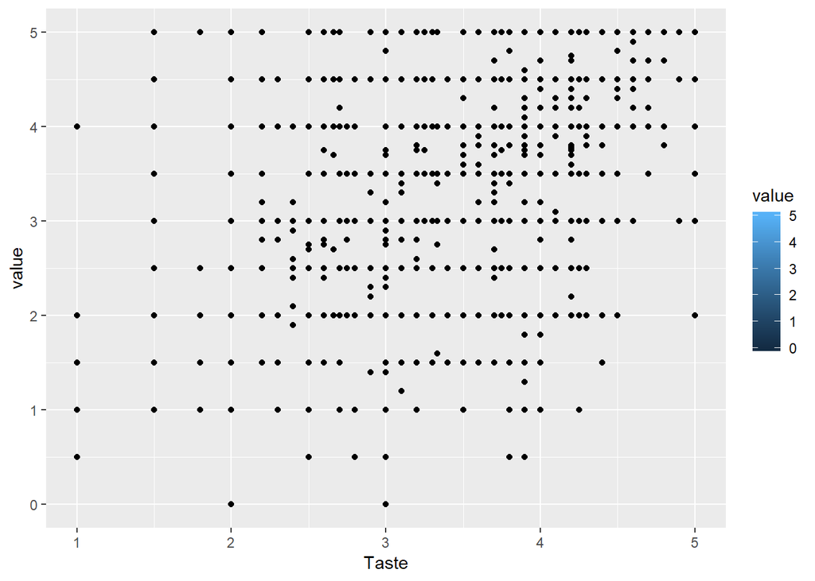

```r
ggplot(df.melt, aes(x = Taste, y = value, fill = value)) + geom_point()
```

14. Create a facet_wrap of df.melt use x-axis=“Taste”, y-axis=“Value” and colour = “variable”, use geom_point, add a smoother(lm) using geom_smooth, colour the smoother in “black”, give the x axis label as ‘Burrito Qulaity’ and y-axis label as ‘score’

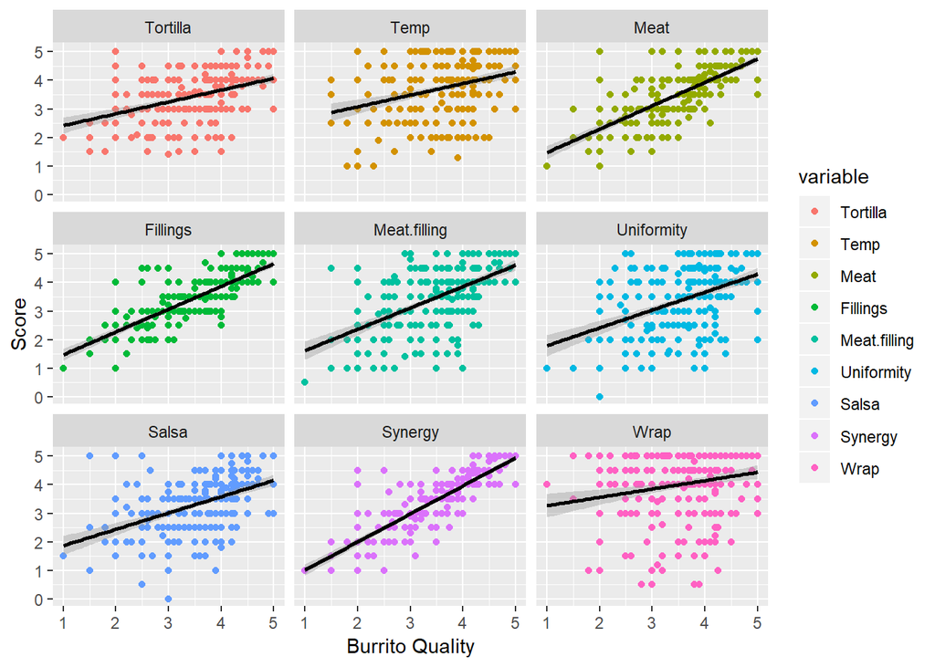

```r
ggplot(df.melt, aes(x = Taste, y = value, color = variable)) +
  geom_point() +
  geom_smooth(method = "lm", color = "black") +
  facet_wrap(~variable) +
  labs(x = "Burrito Quality", y = "Score")
```